# Iteratieve oplossing van een Buck convertor

[bron](https://github.com/wulffern/aic2023/blob/main/jupyter/buck.ipynb)

The output voltage will be an integral of the current $I_x$ and $I_o$

$$V_o = \frac{1}{C} \int{(I_x - I_o)}dt$$

The current through the inductor will be an integral of the voltage across the inductor.

$$I_x = \frac{1}{L} \int{V_x dt}$$

The differential equations are not necessarily that easy to solve. Most of the state variables (V_o,V_x,I_x) are non-linear as a function of time.

I figured that instead of trying the differential equations by hand, we can solve them numerically in Python.

First, some constants, and let's assume A and B are periodic. When A is on, B is off, when B is on, A is off. We can model the A on time by a duty-cycle of the period.

To simulate what happens we need the state variables and time vector

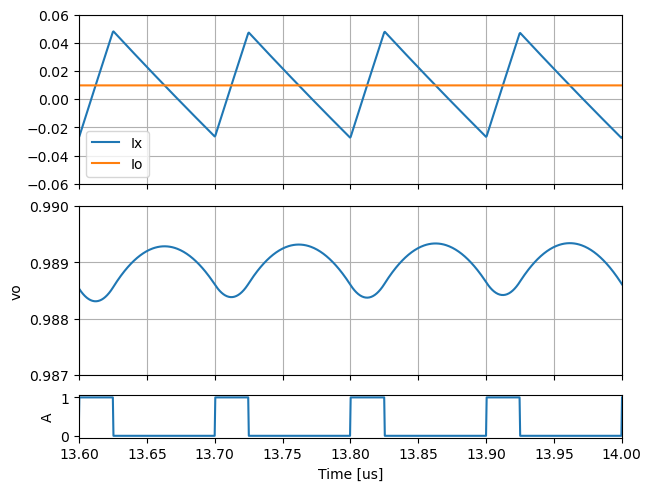

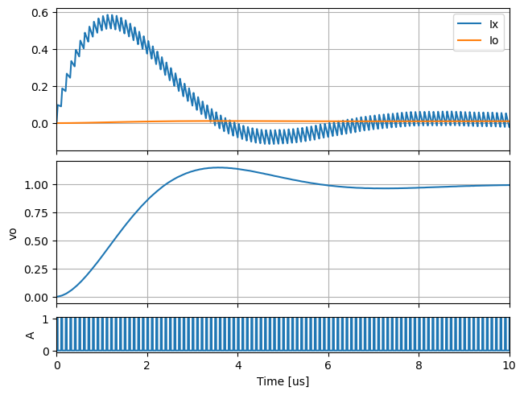

```
Output voltage =  987.6 mV
Inductor current = 13.27 mA
Load current = 9.876 mA
VDDH current = 3.44 mA
VDDH Power = 13.76 mW
VO Power = 9.753 mW
Efficiency = 70.88 pct
```

## What happens when I change the duty cycle?

The output voltage will stabilize at approximately $ V_o = V_{DDH} \times D_{tc}$

## What happens to the output voltage when I change the load current?

Not much. The output voltage drops due to the series resistance in the switches $V_o = V_{DDH} D_{tc} - R_s I_o $

## What happens if the initial output voltage is zero?

We can observe a huge overshoot in the inductor current (Amps). These high currents can kill our device.

## Can I make output voltage independent of input voltage?

Yes. With a feedback loop. If I measure the error in $V_o$ and adjust $D_{tc}$ accordingly, then I can control the output voltage even if the input voltage changes.

I would rather have questions that can't be answered  
than answers that can't be questioned.

Richard Feynman